# Islander Drug Analysis

Kristina Dmytruk

# Islander Dataset Analysis

This analysis explores the effect of different experimental drugs on memory improvement in the Islander dataset. The study evaluates overall memory improvement, compares drug treatments, and investigates potential influences such as dosage, age group, family background, and emotional valence of the memory.

## Research Questions

This analysis aims to answer the following questions:

1. Do participants show overall memory improvement after treatment?
2. Do different drugs produce different levels of improvement?
3. Does drug dosage influence memory improvement?
4. Does age affect treatment response?
5. Does emotional valence influence recall?
6. Do individuals from the same family respond similarly to treatment?

### Load Required Libraries

```r
library(tidyverse)
library(readr)
library(reshape2)
library(ggpubr)
```

### Load dataset

```r
Islander_data <- read_csv(
  "~/Documents/R programming/Elixir course/2025-04-23-R-basic-main/2025-04-23-R-basic-main/data/Islander_data.csv",
  show_col_types = FALSE
)
```

## Data exploration

Inspecting dataset structure and checking for missing values

```r
# Print first 10 rows
head(Islander_data, 10)
```

| first_name | last_name | age | Happy_Sad_group | Dosage | Drug | Mem_Score_Before | Mem_Score_After | Diff |
| --- | --- | --- | --- | --- | --- | --- | --- | --- |
| Bastian | Carrasco | 25 | H | 1 | A | 63.5 | 61.2 | -2.3 |
| Evan | Carrasco | 52 | S | 1 | A | 41.6 | 40.7 | -0.9 |
| Florencia | Carrasco | 29 | H | 1 | A | 59.7 | 55.1 | -4.6 |
| Holly | Carrasco | 50 | S | 1 | A | 51.7 | 51.2 | -0.5 |
| Justin | Carrasco | 52 | H | 1 | A | 47.0 | 47.1 | 0.1 |
| Liam | Carrasco | 37 | S | 1 | A | 66.4 | 58.1 | -8.3 |
| Ava | Durand | 35 | S | 1 | A | 44.1 | 56.0 | 11.9 |
| Jamie | Durand | 38 | H | 1 | A | 76.3 | 74.8 | -1.5 |
| Josefa | Durand | 29 | H | 1 | A | 56.2 | 45.0 | -11.2 |
| Mark | Durand | 36 | S | 1 | A | 54.8 | 75.9 | 21.1 |

```r
# Descriptive statistics
summary(Islander_data)
```

```
##   first_name         last_name              age        Happy_Sad_group
##  Length:198         Length:198         Min.   :24.00   Length:198
##  Class :character   Class :character   1st Qu.:30.00   Class :character
##  Mode  :character   Mode  :character   Median :37.00   Mode  :character
##                                        Mean   :39.53
##                                        3rd Qu.:48.00
##                                        Max.   :83.00
##      Dosage         Drug           Mem_Score_Before Mem_Score_After
##  Min.   :1.00   Length:198         Min.   : 27.20   Min.   : 27.10
##  1st Qu.:1.00   Class :character   1st Qu.: 46.52   1st Qu.: 47.17
##  Median :2.00   Mode  :character   Median : 54.80   Median : 56.75
##  Mean   :1.99                      Mean   : 57.97   Mean   : 60.92
##  3rd Qu.:3.00                      3rd Qu.: 68.40   3rd Qu.: 73.25
##  Max.   :3.00                      Max.   :110.00   Max.   :120.00
##       Diff
##  Min.   :-40.400
##  1st Qu.: -3.175
##  Median :  1.700
##  Mean   :  2.955
##  3rd Qu.:  5.925
##  Max.   : 49.000
```

```r
# Check missing values
colSums(is.na(Islander_data))
```

```
##       first_name        last_name              age  Happy_Sad_group
##                0                0                0                0
##           Dosage             Drug Mem_Score_Before  Mem_Score_After
##                0                0                0                0
##             Diff
##                0
```

### Memory Scores Before and After Treatment

Calculation of the overall average memory scores before and after drug administration

```r
average_memory_score_before <- mean(Islander_data$Mem_Score_Before)
paste('Average before is', average_memory_score_before)
```

```
## [1] "Average before is 57.9676767676768"
```

```r
average_memory_score_after <- mean(Islander_data$Mem_Score_After)
paste('Average after is', average_memory_score_after)
```

```
## [1] "Average after is 60.9222222222222"
```

```r
t_test_memory_improvment <- t.test(
  Islander_data$Mem_Score_After,
  Islander_data$Mem_Score_Before,
  paired = TRUE
)
t_test_memory_improvment
```

```
##
##  Paired t-test
##
## data:  Islander_data$Mem_Score_After and Islander_data$Mem_Score_Before
## t = 3.8657, df = 197, p-value = 0.0001504
## alternative hypothesis: true mean difference is not equal to 0
## 95 percent confidence interval:
##  1.447293 4.461798
## sample estimates:
## mean difference
##        2.954545
```

### Data exploration conclusion

According to paired t-test we can conclude that there is a significant difference in the memory score after drug administration.

## Within-drug effect

### Memory improvement summary by Drug

```r
Islander_data %>%
  group_by(Drug) %>%  #part 1
  summarize(
    Mean = mean(Diff, na.rm = TRUE), #the average diff in memory scores
    Median = median(Diff, na.rm = TRUE), #median
    Standard_deviation = sd(Diff, na.rm = TRUE) #variance - standard deviation
)
```

| Drug | Mean | Median | Standard_deviation |
| --- | --- | --- | --- |
| A | 9.4701493 | 7.9 | 13.253930 |
| S | -0.1712121 | 0.3 | 7.499923 |
| T | -0.5876923 | 0.2 | 7.104521 |

### Introducing color-coding for each drug

```r
drug_colors <- c("A" = "red", "S" = "green", "T" = "blue")
```

### Memory improvement comparison visualization

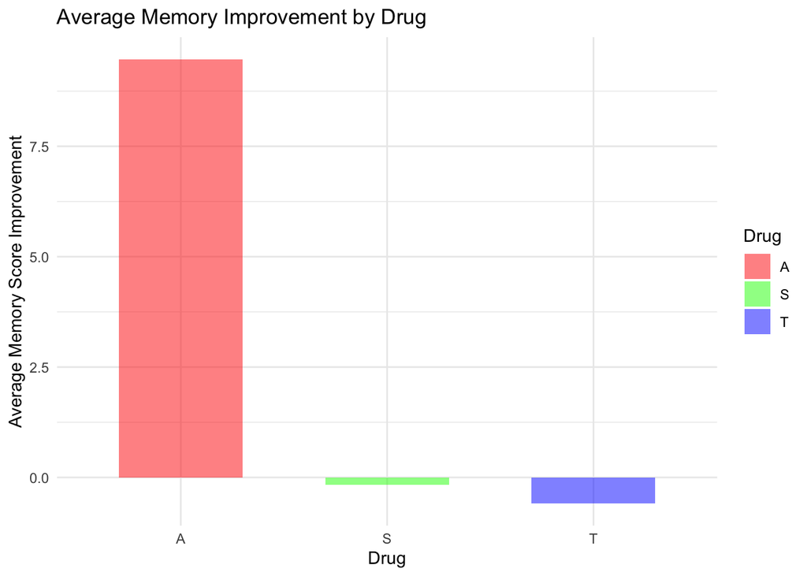

```r
summary_plot <- Islander_data %>%
  group_by(Drug) %>%
  summarise(mean_diff = mean(Diff, na.rm = TRUE)) %>%
  ggplot(aes(x = Drug, y = mean_diff, fill = Drug)) +
  geom_col(width = 0.6, alpha=0.5) +
  theme_minimal() +
  labs(
    title = "Average Memory Improvement by Drug",
    x = "Drug",
    y = "Average Memory Score Improvement"
  ) +
  scale_fill_manual(values = drug_colors)

summary_plot
```

```r
ggsave(
  filename = "Memory_improvement_summary.pdf",
  plot = summary_plot,
  width = 8,
  height = 5
)
```

### Paired t-tests for Memory Improvement by Drug

To determine whether memory scores significantly improved after treatment, paired t-tests are performed for each drug separately.

```r
t_test_memory_improvment_A <- t.test(
  Islander_data$Mem_Score_After[Islander_data$Drug == "A"],
  Islander_data$Mem_Score_Before[Islander_data$Drug == "A"],
  paired = TRUE
)
t_test_memory_improvment_A
```

```
##
##  Paired t-test
##
## data:  Islander_data$Mem_Score_After[Islander_data$Drug == "A"] and Islander_data$Mem_Score_Before[Islander_data$Drug == "A"]
## t = 5.8486, df = 66, p-value = 1.69e-07
## alternative hypothesis: true mean difference is not equal to 0
## 95 percent confidence interval:
##   6.237262 12.703037
## sample estimates:
## mean difference
##        9.470149
```

```r
t_test_memory_improvment_S <- t.test(
  Islander_data$Mem_Score_After[Islander_data$Drug == "S"],
  Islander_data$Mem_Score_Before[Islander_data$Drug == "S"],
  paired = TRUE
)
t_test_memory_improvment_S
```

```
##
##  Paired t-test
##
## data:  Islander_data$Mem_Score_After[Islander_data$Drug == "S"] and Islander_data$Mem_Score_Before[Islander_data$Drug == "S"]
## t = -0.18546, df = 65, p-value = 0.8534
## alternative hypothesis: true mean difference is not equal to 0
## 95 percent confidence interval:
##  -2.014923  1.672499
## sample estimates:
## mean difference
##      -0.1712121
```

```r
t_test_memory_improvment_T <- t.test(
  Islander_data$Mem_Score_After[Islander_data$Drug == "T"],
  Islander_data$Mem_Score_Before[Islander_data$Drug == "T"],
  paired = TRUE
)
t_test_memory_improvment_T
```

```
##
##  Paired t-test
##
## data:  Islander_data$Mem_Score_After[Islander_data$Drug == "T"] and Islander_data$Mem_Score_Before[Islander_data$Drug == "T"]
## t = -0.66692, df = 64, p-value = 0.5072
## alternative hypothesis: true mean difference is not equal to 0
## 95 percent confidence interval:
##  -2.348106  1.172722
## sample estimates:
## mean difference
##      -0.5876923
```

### Within-drug effect conclusion

Paired t-tests indicate that Drug A produces a statistically significant improvement in memory scores relative to baseline.  
Drugs S and T do not show statistically significant improvements when analyzed separately.

## Between-drug comparison

```r
model <- lm(Diff ~ Drug, data = Islander_data)
anova(model)
```

|  | Df | Sum Sq | Mean Sq | F value | Pr(>F) |
| --- | --- | --- | --- | --- | --- |
| Drug | 2 | 4304.785 | 2152.39258 | 22.71129 | 1.359214e-09 |
| Residuals | 195 | 18480.526 | 94.77193 | NA | NA |

```r
tukey_results <- TukeyHSD(aov(model))
tukey_results
```

```
##   Tukey multiple comparisons of means
##     95% family-wise confidence level
##
## Fit: aov(formula = model)
##
## $Drug
##            diff       lwr       upr     p adj
## S-A  -9.6413614 -13.62876 -5.653958 0.0000001
## T-A -10.0578416 -14.06067 -6.055017 0.0000000
## T-S  -0.4164802  -4.43421  3.601249 0.9675045
```

### Visual exploration: box plots

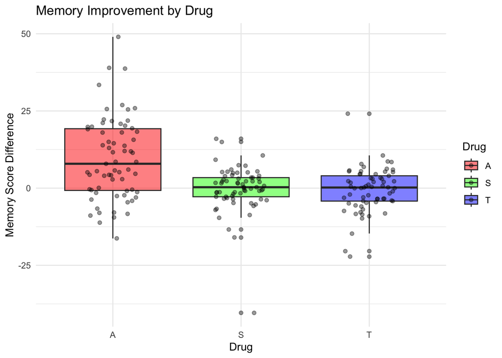

```r
Memory_improvment_by_drug <- ggplot(Islander_data, aes(x = Drug, y = Diff, fill = Drug)) +
  geom_boxplot(alpha = 0.5) +
  geom_jitter(width = 0.2, alpha = 0.4) +
  theme_minimal() +
  labs(
    title = "Memory Improvement by Drug",
    y = "Memory Score Difference"
  ) +
  scale_fill_manual(values = drug_colors)

Memory_improvment_by_drug
```

```r
ggsave(
  filename = "Memory_Improvment_by_Drug.pdf",
  plot = Memory_improvment_by_drug,
  width = 8,
  height = 5
)
```

### Between-drug conclusion

The linear model and ANOVA indicate a significant effect of drug treatment on memory improvement (F(2,195) = 22.71, p < 0.001).

Post-hoc Tukey comparisons show:

- Drug A improves memory significantly better than Drug S (p < 0.001) and Drug T (p < 0.001).
- No significant difference is observed between Drugs S and T (p = 0.968).

## Dosage-response analysis

The dose–response shows how memory improvement changes with increasing drug dosage.

If improvement increases with dosage, this suggests a potential dose-dependent treatment effect.

```r
dosage_summary <- Islander_data %>%
  group_by(Drug, Dosage) %>%
  summarise(
    mean_diff = mean(Diff, na.rm = TRUE)
  ) %>%
  arrange(desc(Drug), mean_diff) %>%
  mutate(Dosage = factor(Dosage))  # convert Dosage to factor
```

```
## `summarise()` has regrouped the output.
## ℹ Summaries were computed grouped by Drug and Dosage.
## ℹ Output is grouped by Drug.
## ℹ Use `summarise(.groups = "drop_last")` to silence this message.
## ℹ Use `summarise(.by = c(Drug, Dosage))` for per-operation grouping
##   (`?dplyr::dplyr_by`) instead.
```

### Visualization: Dose–Response Relationship

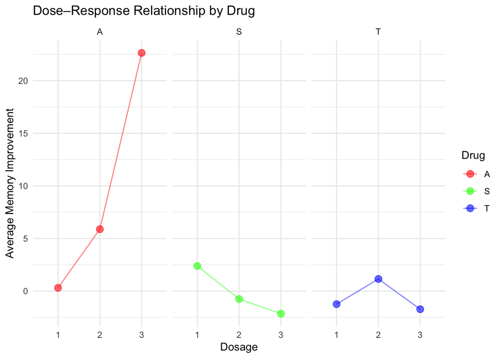

```r
dosage_effect <- ggplot(dosage_summary, aes(x = Dosage, y = mean_diff, color = Drug, group = Drug)) +
  geom_line(alpha = 0.5) +
  geom_point(size = 3, alpha = 0.6) +
  facet_wrap(~Drug) +
  theme_minimal() +
  labs(
    title = "Dose–Response Relationship by Drug",
    x = "Dosage",
    y = "Average Memory Improvement"
  ) +
  scale_color_manual(values = drug_colors)

dosage_effect
```

```r
#Save the plot as a PDF file
ggsave(
  filename = "Dosage_effect.pdf",
  plot = dosage_effect,
  width = 8,
  height = 5
)
```

## Age_group analysis

```r
#Add new column age_group
Islander_data <- Islander_data %>%
  mutate(
    Age_group = case_when(
      age < 30 ~ 'Young',
      age > 50 ~ 'Senior',
      TRUE ~ 'Middle age'
    ),
    Age_group = factor(Age_group, levels = c("Young", "Middle age", "Senior"))
  )

#Group by Age_group and Drug
Islander_data %>%
  group_by(Age_group, Drug) %>%
  summarise(
    mean_diff = mean(Diff, na.rm = TRUE)
  )
```

```
## `summarise()` has regrouped the output.
## ℹ Summaries were computed grouped by Age_group and Drug.
## ℹ Output is grouped by Age_group.
## ℹ Use `summarise(.groups = "drop_last")` to silence this message.
## ℹ Use `summarise(.by = c(Age_group, Drug))` for per-operation grouping
##   (`?dplyr::dplyr_by`) instead.
```

| Age_group | Drug | mean_diff |
| --- | --- | --- |
| Young | A | 4.4875000 |
| Young | S | 2.2315789 |
| Young | T | 0.8928571 |
| Middle age | A | 12.7600000 |
| Middle age | S | -1.5820513 |
| Middle age | T | -0.9864865 |
| Senior | A | 7.2562500 |
| Senior | S | 1.0000000 |
| Senior | T | -1.0142857 |

### Statistics: does age group affects response to Drug A

To determine whether the effectiveness of Drug A varies across age groups, a linear model was fitted with memory improvement as the dependent variable and age group as the predictor.

The ANOVA test evaluates whether the average improvement differs between age groups.

```r
age_effect_model <- Islander_data %>%
  filter(Drug == "A") %>%
  lm(Diff ~ Age_group, data = .)

summary(age_effect_model)
```

```
##
## Call:
## lm(formula = Diff ~ Age_group, data = .)
##
## Residuals:
##     Min      1Q  Median      3Q     Max
## -23.556  -8.158  -0.487   7.590  36.240
##
## Coefficients:
##                     Estimate Std. Error t value Pr(>|t|)
## (Intercept)            4.488      3.238   1.386   0.1707
## Age_groupMiddle age    8.272      3.909   2.116   0.0382 *
## Age_groupSenior        2.769      4.580   0.605   0.5476
## ---
## Signif. codes:  0 '***' 0.001 '**' 0.01 '*' 0.05 '.' 0.1 ' ' 1
##
## Residual standard error: 12.95 on 64 degrees of freedom
## Multiple R-squared:  0.0737, Adjusted R-squared:  0.04475
## F-statistic: 2.546 on 2 and 64 DF,  p-value: 0.08631
```

```r
anova(age_effect_model)
```

|  | Df | Sum Sq | Mean Sq | F value | Pr(>F) |
| --- | --- | --- | --- | --- | --- |
| Age_group | 2 | 854.4594 | 427.2297 | 2.545984 | 0.08631317 |
| Residuals | 64 | 10739.5409 | 167.8053 | NA | NA |

### Age group effect conclusion

There is no statistically significant effect of age group on the efficacy of Drug A at the 0.05 significance level.

### Visualization: Strength of Drug A effect on different age groups

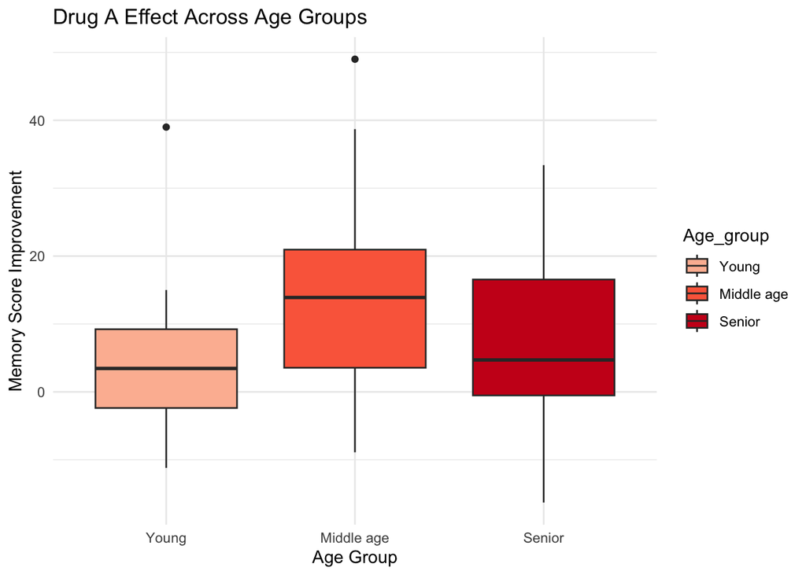

```r
#Visualization: Drug_A_effect_across_age_group
Drug_A_effect_accross_age_group <- Islander_data %>%
  filter(Drug == "A") %>%
  ggplot(aes(x = Age_group, y = Diff, fill = Age_group)) +
  geom_boxplot(alpha = 1) +
  theme_minimal() +
  labs(
    title = "Drug A Effect Across Age Groups",
    x = "Age Group",
    y = "Memory Score Improvement"
  ) +
  scale_fill_manual(values = c(
    "Young" = "#fcbba1",
    "Middle age" = "#fb6a4a",
    "Senior" = "#cb181d"
  ))

Drug_A_effect_accross_age_group
```

```r
#Save the plot as a PDF file
ggsave(
  filename = "Drug_A_effect_across_age_group.pdf",
  plot = Drug_A_effect_accross_age_group,
  width = 8,
  height = 5
)
```

## Memories emotional valence analysis

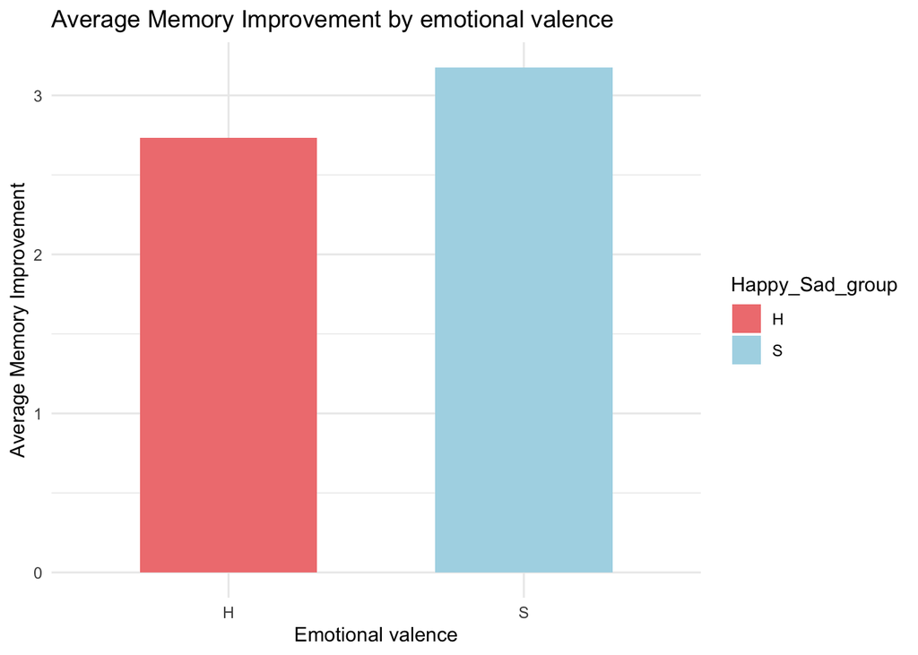

```r
emotion_summary <- Islander_data %>%
  group_by(Happy_Sad_group) %>%
  summarise(
    mean_diff = mean(Diff, na.rm = TRUE),
    .groups = "drop"
  )

#Visualization:
emotion_effect <- ggplot(emotion_summary, aes(x = Happy_Sad_group, y = mean_diff, fill = Happy_Sad_group)) +
  geom_col(width = 0.6) +
  theme_minimal() +
  scale_fill_manual(values = c(S = "lightblue", H = "lightcoral")) +
  labs(
    title = "Average Memory Improvement by emotional valence",
    x = "Emotional valence",
    y = "Average Memory Improvement"
  )
emotion_effect
```

```r
#Save the plot as a PDF file
ggsave(
  filename = "Drug_effect_emotional_valence.pdf",
  plot = emotion_effect,
  width = 8,
  height = 5
)
```

### Statistics: does emotional valence influence recall after drugs administration?

```r
mood_t_test <- t.test(
  Diff ~ Happy_Sad_group,
  data = Islander_data
)

mood_t_test
```

```
##
##  Welch Two Sample t-test
##
## data:  Diff by Happy_Sad_group
## t = -0.28876, df = 194.76, p-value = 0.7731
## alternative hypothesis: true difference in means between group H and group S is not equal to 0
## 95 percent confidence interval:
##  -3.464183  2.579334
## sample estimates:
## mean in group H mean in group S
##        2.733333        3.175758
```

### Emotional valence conclusion:

No significant difference observed in recall improvement between happy and sad memories.

However, there could be difference in recall improvement between happy and sad memories for certain drug.

## Genetical background: response to treatment by family

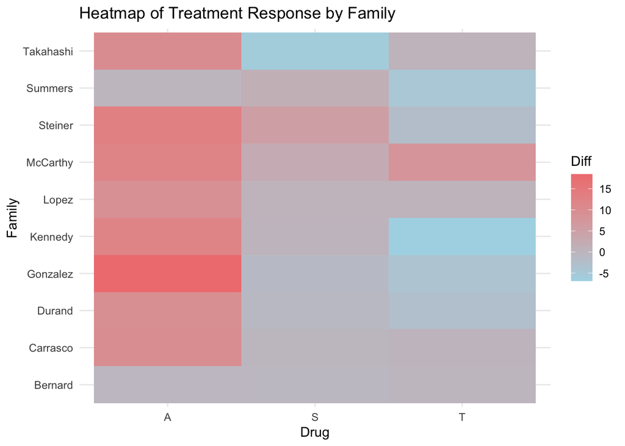

```r
#Add column Family
Islander_data <- Islander_data %>%
  mutate(Family = factor(last_name))

#Heatmap: Response to treatment by family and drug
Islander_data_filtered <- Islander_data %>%
  group_by(Family) %>%
  filter(n_distinct(Drug) == 3) %>%  # Assuming 3 unique treatments
  ungroup()

#Reshape data without aggregation
data_matrix <- dcast(Islander_data_filtered, Family ~ Drug, value.var = "Diff", fun.aggregate = mean)  # using mean or any other aggregation if needed

#Melt the data to long format for plotting
data_long <- melt(data_matrix, id.vars = "Family", variable.name = "Drug", value.name = "Diff")

#Plot the heatmap
Heatmap_TreatmentResponse_ByFamile <- ggplot(data_long, aes(x = Drug, y = Family, fill = Diff)) +
  geom_tile() +
  scale_fill_gradient(low = "lightblue", high = "lightcoral") +
  theme_minimal() +
  labs(x = "Drug", y = "Family", title = "Heatmap of Treatment Response by Family")

Heatmap_TreatmentResponse_ByFamile
```

```r
#Save the plot as a PDF file
ggsave(
  filename = "Heatmap_TreatmentResponse_ByFamile.pdf",
  plot = Heatmap_TreatmentResponse_ByFamile,
  width = 8,
  height = 5
)
```

### Genetical background conclusion

Members of different families were treated with one of the experimental drugs. The heatmap indicates that noticeable memory improvement is primarily observed among participants who received Drug A. This observation is consistent with the earlier statistical analysis, which showed that only Drug A produces a significant improvement in memory scores relative to baseline.

Overall, these results suggest that the positive effect of Drug A on memory performance does not appear to depend strongly on family background, implying that genetic differences between families are unlikely to be a major driver of the observed improvement. At the same time, the heatmap shows that some families did not experience noticeable improvement under any treatment, indicating that individual or family-level factors may still influence responsiveness to the drugs.

## Final Conclusion

The present analysis investigated the effect of experimental drugs on memory improvement using the Islander dataset. Several statistical approaches were applied to evaluate treatment effects and explore potential factors influencing drug response.

A paired t-test comparing memory scores before and after treatment demonstrated a statistically significant improvement in memory performance following drug administration (t = 3.87, p < 0.001), indicating that treatment overall was associated with enhanced recall ability.

To determine whether different drugs produced different effects, a linear model followed by ANOVA and Tukey post-hoc tests was conducted. These analyses revealed a significant effect of drug type on memory improvement (F(2,195) = 22.71, p < 0.001). Post-hoc comparisons showed that Drug A resulted in significantly greater improvement than both Drug S and Drug T, while no significant difference was observed between Drugs S and T.

Further analyses investigated potential moderating factors. Dose–response patterns suggested that higher dosages may be associated with increased memory improvement, particularly for Drug A. Age group analysis indicated modest differences in response, with middle-aged participants showing slightly higher improvements compared to younger participants, although overall age effects were limited.

Finally, examination of family-level patterns using a heatmap suggested that the beneficial effect of Drug A was broadly consistent across families. While some families did not show strong responses to any treatment, the overall pattern indicates that genetic background is unlikely to be the primary driver of the observed treatment effect.

Taken together, the results indicate that Drug A demonstrates the most promising effect on memory improvement among the tested treatments. These findings highlight the importance of drug selection in cognitive enhancement studies and suggest that Drug A warrants further investigation in controlled experimental settings.